# Part I - (Flights Dataset Exploration)

### Did you observe any interesting relationships between the other features (not the main feature(s) of interest)?

> - Business Strategies in Heatmap Visualization:
>   - The heatmap indicates differing business strategies among airlines. For example, airlines with minor fluctuations in flight frequencies might be focusing on business travelers who require consistent, year-round service. Meanwhile, those with significant peaks and troughs might be capitalizing on seasonal tourist traffic, adjusting their capacities to meet fluctuating demands effectively.
> - Operational Efficiency and Network Size:
>   - Larger airlines or those with extensive networks might have the resources or strategies in place to manage or mitigate the impact of potential delays more effectively than smaller airlines. This is reflected in how compact their delay distributions are, despite managing a high volume of flights. Conversely, smaller or budget airlines may struggle more with operational disruptions, leading to more frequent or severe delays.

## Multivariate Exploration

> Create plots of three or more variables to investigate your data even further. Make sure that your investigations are justified, and follow from your work in the previous sections.

```python
# df['Year'] = pd.to_datetime(df['FlightDate']).dt.year  # Ensure 'Year' is extracted correctly if only FlightDate is available
delay_types = ['CarrierDelay', 'WeatherDelay', 'NASDelay', 'SecurityDelay', 'LateAircraftDelay']

# Aggregate delay minutes by year and delay type
annual_delays = df.groupby(['Year'])[delay_types].sum().reset_index()
```

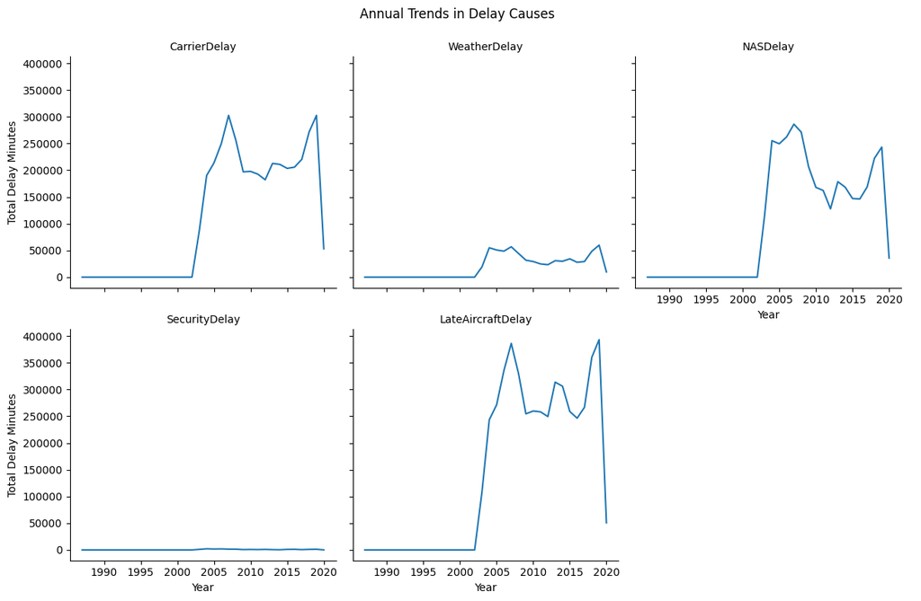

```python
g = sns.FacetGrid(annual_delays.melt(id_vars=['Year'], value_vars=delay_types, var_name='DelayType', value_name='TotalMinutes'), col='DelayType', col_wrap=3, height=4)
g.map(sns.lineplot, 'Year', 'TotalMinutes')
g.add_legend()
g.set_axis_labels('Year', 'Total Delay Minutes')
g.set_titles('{col_name}')
plt.subplots_adjust(top=0.9)
g.fig.suptitle('Annual Trends in Delay Causes')
plt.show()
```

```python
# Calculate average delay and count flights per year
summary_data = df.groupby('Year').agg(TotalFlights=('Flight_Number_Reporting_Airline', 'count'), AverageDelay=('DepDelayMinutes', 'mean')).reset_index()
```

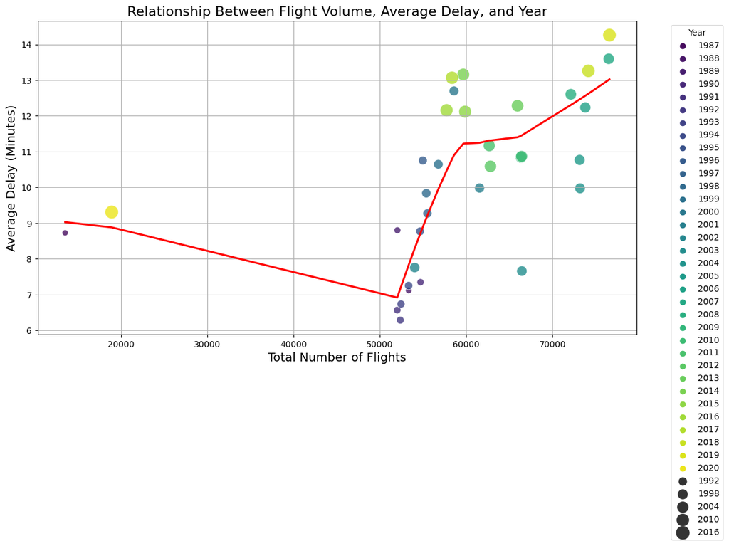

```python
# Scatter plot with improvements
plt.figure(figsize=(12, 8))
custom_palette =sns.color_palette("viridis", n_colors=summary_data.shape[0])
sns.scatterplot(data=summary_data, x='TotalFlights', y='AverageDelay', hue='Year', size='Year',
                sizes=(50, 250), palette=custom_palette, alpha=0.8)

# Adding a LOESS(Locally Estimated Scatterplot Smoothing) curve to show trend
sns.regplot(data=summary_data, x='TotalFlights', y='AverageDelay', scatter=False, color='red', lowess=True)

plt.title('Relationship Between Flight Volume, Average Delay, and Year', fontsize=16)
plt.xlabel('Total Number of Flights', fontsize=14)
plt.ylabel('Average Delay (Minutes)', fontsize=14)
plt.legend(title='Year', bbox_to_anchor=(1.05, 1), loc='upper left')
plt.grid(True)  # Adding grid for better readability
plt.tight_layout()  # Adjust layout to make room for the legend outside the plot area
plt.show()
```